# Simulating confidence intervals and Introducing the Jackknife and Bootstrap

Recall the concept of the **sampling distribution of a statistic** – this is simply the probability distribution of the statistic of interest you would observe if you took a large number of random samples of a given size from a population of interest and calculated that statistic for each of the samples. In the previous lecture you used simulation to approximate the sampling distribution a number of different statistics.

To use simulation to approximate a sampling distribution we carried out the following steps:

1. Made some assumptions about the distributional properties of the underlying population
2. Simulate drawing random samples of a given size from that population
3. For each simulated random sample, calculate the statistic(s) of interest
4. Treat the simulated distribution of the statistics of interest as the sampling distribution

You learned that the standard deviation of the sampling distribution of a statistic has a special name – the **standard error** of that statistic. The standard error of a statistic provides a way to quantify the uncertainty of a statistic across random samples. Here we show how to use information about the standard error of a statistic to calculate confidence intervals for a statistic based on a set of observed data.

## Libraries

```r
library(tidyverse)
library(magrittr)
```

## Confidence Intervals

We know that given a random sample from a population of interest, the value of a statistic of interest is unlikely to be exactly equally to the true population value of that statistics. However, our simulations have taught us a number of things:

1. As sample size increases, the sample estimate of the given statistic is more likely to be close to the true value of that statistic
2. As sample size increases, the standard error of the statistic decreases

We can use this knowledge to calculate a *plausible ranges of values* for the statistic of interest. We call such ranges **confidence intervals** for the statistic of interest.

## Calibrating confidence intervals

How are we to calibrate “plausible ranges”? We will define an “X% percent confidence interval for a statistic of interest”, as an interval that when calculated from a random sample, would include the true population value of the statistic X% of the time.

This quote from the [NIST page on confidence intervals](http://www.itl.nist.gov/div898/handbook/eda/section3/eda352.htm) helps to make this concrete regarding confidence intervals for he mean:

> As a technical note, a 95 % confidence interval does not mean that there is a 95 % probability that the interval contains the true mean. The interval computed from a given sample either contains the true mean or it does not. Instead, **the level of confidence is associated with the method of calculating the interval** … That is, for a 95% confidence interval, if many samples are collected and the confidence interval computed, in the long run about 95% of these intervals would contain the true mean.

## Standard formulation for confidence intervals

We define the $(100\times\beta)$% confidence interval for the statistic $\phi$ as the interval:

$$CI_\beta = \phi_{i,n} \pm (z \times {SE}_{\phi,n})$$

Where:

- $\phi_i,n$ is the statistic of interest in a random sample of size $n$
- ${SE}_{\phi,n}$ is the standard error of the statistic $\phi$ (via simulation or analytical solution)

And the value of $z$ is chosen so that:

- across many different random samples of size $n$, the true value of the $\phi$ in the population of interest would fall within the interval approximately $CI_\beta$ $(100\times\beta)$% of the time

So rather than estimating a single value of $\phi$ from our data, we will use our observed data plus knowledge about the sampling distribution of $\phi$ to estimate a range of plausible values for $\phi$. The size of this interval will be chosen so that if we considered many possible random samples, the true population value of $\phi$ would be bracketed by the interval in $(100\times\beta)$% of the samples.

## Example

```r
set.seed(20180328)

# Assume underlying population
mu = 4

sample.distn.mean <- replicate(10000, mean(rpois(25, mu)))

df <- data_frame(means = sample.distn.mean)
```

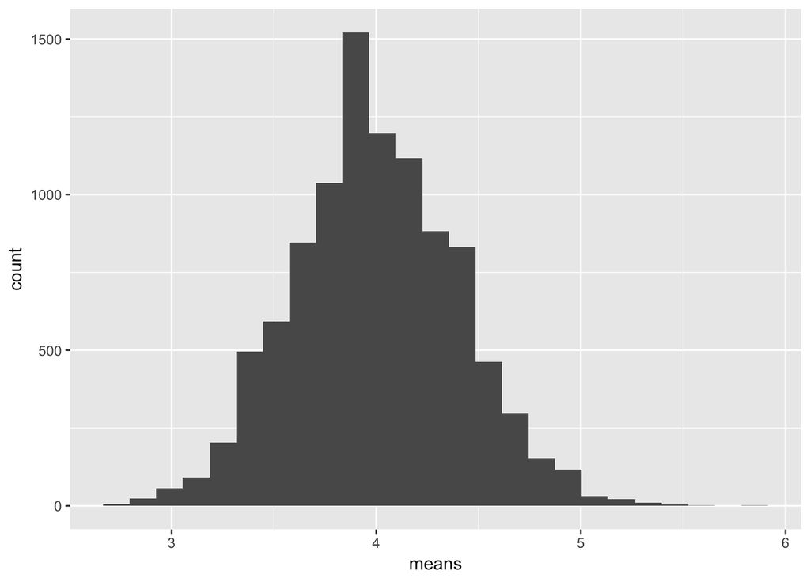

```r
ggplot(df, aes(x = means)) +
  geom_histogram(bins=25)
```

```r
sample.sizes <- c(3:10, seq(12,30,by=2), seq(40,100,by=10))


simulated.samples <-
  sample.sizes %>%
  map(function(x) rerun(5000, rpois(x, mu))) %>%
  flatten

simulated.stats <-
  simulated.samples %>%
  map_dfr(function(x) list(n = length(x), mean=mean(x), sd = sd(x)))

stats.of.sampling.distns <-
  simulated.stats %>%
  group_by(n) %>%
  summarize(se.mean = sd(mean), se.sd = sd(sd))
```

```r
simulate.poisson.sampling.distn <- function(mu, ssizes, nsims = 1000) {
  simulated.samples <-
    ssizes %>%
    map(function(x) rerun(nsims, rpois(x, mu))) %>%
    flatten

  simulated.stats <-
    simulated.samples %>%
    map_dfr(function(x) list(true.mu = mu, n = length(x), mean=mean(x), sd = sd(x)))

  stats.of.sampling.distns <-
    simulated.stats %>%
    group_by(n) %>%
    summarize(true.mu = as.integer(mean(true.mu)), se.mean = sd(mean), se.sd = sd(sd))

  return(stats.of.sampling.distns)
}
```

```r
sample.sizes <- c(3:10, seq(12,30,by=2), seq(40,100,by=10))
means <- 1:10


w <- means %>%
  map(function(x) simulate.poisson.sampling.distn(x, sample.sizes, nsims=5000)) %>%
  bind_rows
```